# Assignment_4_6783

```python
%%html
<style>
table {float:left}
</style>
```

### Group Members:

[output not shown]

#### Part I: Gaussian Mixtures

#### Introduction

Implement the EM algorithm from scratch for a p-dimensional Gaussian mixture model with G components.

$$\sum_{k=1}^{G} p_{k}·N(x;μk,Σ)$$

#### Requirements

Your implementation should consists of four functions.

Estep function: This function should return an n-by-G matrix, where the (i,j)th entry represents the conditional probability P(Zi = k | xi). Here i ranges from 1 to n and k ranges from 1 to G.

Mstep function: This function should return the updated parameters for the Gaussian mixture model.

loglik function: This function computes the log-likelihood of the data given the parameters.

myEM function (main function): Inside this function, you can call the Estep and Mstep functions. The function should take the following inputs and return the estimated parameters and log-likelihood (via the loglik function):

#### Input:

∗ data: The dataset.

∗ G: The number of components. Although your code will be tested with G = 2 and G = 3, it  
should be able to handle any value of G. (You can, of course, ignore the case where G > n.)

∗ Initial parameters.

∗ itmax: The number of iterations.

#### Output:

∗ prob: A G-dimensional probability vector (p1 , . . . , pG )

∗ mean: A p-by-G matrix with the k-th column being μk, the p-dimensional mean for the k-th  
Gaussian component.

∗ Sigma: A p-by-p covariance matrix Σ shared by all G components;  
1

∗ loglik: A number equal to

$$\sum_{i=1}^{n} log[\sum_{k=1}^{G} p_{k}·N(x;μk,Σ)]$$

```python
from matplotlib.colors import LogNorm
import matplotlib.pyplot as plt
import numpy as np
import pandas as pd
import seaborn as sns


import warnings
warnings.filterwarnings('ignore')
```

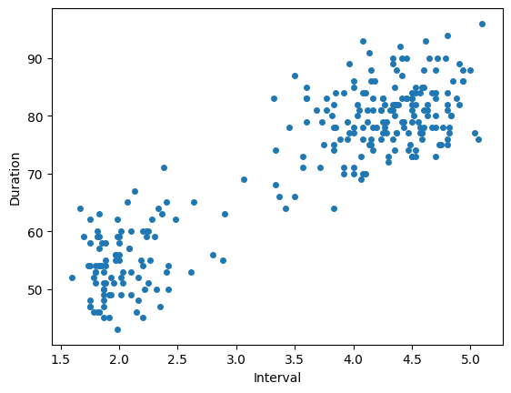

```python
data = pd.read_table("faithful.dat", sep="\s+", index_col=0)
plt.scatter(data['eruptions'], data['waiting'], 16)
plt.xlabel('Interval')
plt.ylabel('Duration')
```

```python
def myEM(X, G, initial_probs, initial_means, initial_cov, itmax):
    probs, means, cov = initial_probs, initial_means, initial_cov
    log_likelihoods = []

    # 檢查 initial_probs, initial_means 和 initial_cov 的形狀
    if probs.shape[0] != G:
        raise ValueError("initial_probs 的大小不正確，應該為 (G,)")
    if means.shape[1] != G:
        raise ValueError("initial_means 的大小不正確，應該為 (d, G)")
    if cov.shape[0] != cov.shape[1]:
        raise ValueError("initial_cov 必須是方陣，共變異數矩陣")

    for _ in range(itmax):
        responsibilities = Estep(X, G, means, cov, probs)
        probs, means, cov = Mstep(X, responsibilities)
        log_likelihood = loglik(X, G, means, cov, probs)
        log_likelihoods.append(log_likelihood)

    return probs, means, cov, log_likelihoods[-1]
```

```python
def Estep(data, G, means, cov, probs):
    n, p = data.shape
    responsibilities = np.zeros((n, G))

    inv_cov = np.linalg.inv(cov)  # 共變異數的逆矩陣
    coef = 1 / np.sqrt((2 * np.pi) ** p * np.linalg.det(cov))  # 高斯分布的歸一化係數

    for k in range(G):
        diff = data - means[:, k]
        exponent = -0.5 * np.sum((diff @ inv_cov) * diff, axis=1)
        responsibilities[:, k] = probs[k] * coef * np.exp(exponent)

    responsibilities /= responsibilities.sum(axis=1, keepdims=True)  # 對每個資料點的責任度進行歸一化
    return responsibilities
```

```python
def Mstep(data, responsibilities):
    n, p = data.shape  # n 是資料點數量，p 是特徵維度
    G = responsibilities.shape[1]  # G 是高斯成分的數量

    # 更新成分機率 probs (每個成分在所有資料點中的責任度總和，然後平均化)
    probs = responsibilities.sum(axis=0) / n

    # 更新均值 means
    # 使用加上小值的分母，避免分母為零的情況
    responsibility_sums = responsibilities.sum(axis=0) + 1e-10  # 避免分母為零
    means = (data.T @ responsibilities) / responsibility_sums  # 計算每個成分的均值，形狀為 (p, G)

    # 更新共變異數 Sigma
    Sigma = np.zeros((p, p))  # 初始化共變異數矩陣為零矩陣 (p, p)

    for k in range(G):
        diff = data - means[:, k].T  # 計算每個資料點到成分 k 的均值的偏差，形狀為 (n, p)
        weighted_diff = responsibilities[:, k][:, np.newaxis] * diff  # 對偏差加權
        Sigma += weighted_diff.T @ diff  # 累加每個成分的共變異數

    Sigma /= n  # 除以資料點數量 n，得到平均共變異數矩陣

    return probs, means, Sigma
```

```python
def loglik(data, G, means, cov, probs):
    n, p = data.shape
    log_likelihood = 0.0

    inv_cov = np.linalg.inv(cov)
    coef = 1 / np.sqrt((2 * np.pi) ** p * np.linalg.det(cov))

    for i in range(n):
        inner_sum = 0
        for k in range(G):
            diff = data[i] - means[:, k]
            exponent = -0.5 * diff.T @ inv_cov @ diff
            inner_sum += probs[k] * coef * np.exp(exponent)
        log_likelihood += np.log(inner_sum)

    return log_likelihood
```

```python
def init_param(X, G, data_split_count):
    n, d = X.shape

    # 確認 data_split_count 是否與 G 對應
    if len(data_split_count) != G:
        raise ValueError("data_split_count 的大小應該等於 G")

    # 設定每個成分的初始機率 p，並確保其為一維向量且大小為 G
    p = np.array(data_split_count) / n
    p = p[:G]  # 確保 p 的大小為 G，且為一維陣列
    print(f"Initial p (probs): {p}")  # 檢查 p 的值

    # 計算均值 mean
    mean = np.zeros((d, G))
    mean[:, 0] = np.mean(X[:data_split_count[0]], axis=0)
    mean[:, 1] = np.mean(X[data_split_count[0]:], axis=0)

    # 計算共變異數 sigma，使用全部資料
    diff1 = X[:data_split_count[0]] - mean[:, 0]
    diff2 = X[data_split_count[0]:] - mean[:, 1]
    sigma = (diff1.T @ diff1 + diff2.T @ diff2) / n

    return p, mean, sigma
```

#### Two component mixture

```python
G = 2
data = data.to_numpy()  # 假設一開始 `data` 是 DataFrame，這行僅需要執行一次以轉換為 numpy 陣列
n = data.shape[0]  # 使用資料的行數作為總樣本數
data_split_count = np.array([10, n - 10])  # 第一個成分有 10 個樣本，第二個成分包含剩下的樣本

# 初始化參數
(prob, mean, sigma) = init_param(X=data, G=G, data_split_count=data_split_count)

# 執行 EM 演算法
(prob, mean, sigma, loglik_val) = myEM(X=data, G=G, initial_probs=prob, initial_means=mean, initial_cov=sigma, itmax=20)
print(f"prob")
print(f"{prob}")
print(f"mean")
print(f"{mean.T}")
print(f"sigma")
print(f"{sigma}")
print(f"loglik")
print(f"{loglik_val}")
```

```
Initial p (probs): [0.03676471 0.96323529]
prob
[0.04297883 0.95702117]
mean
[[ 3.49564188 76.79789153]
 [ 3.48743016 70.63205853]]
sigma
[[  1.29793612  13.92433626]
 [ 13.92433626 182.58009248]]
loglik
-1289.569354943037
```

#### Part II: HMM

#### Objective

Implement the Baum-Welch (i.e., EM) algorithm and the Viterbi algorithm from scratch for a Hidden Markov Model (HMM) that produces an outcome sequence of discrete random variables with three distinct values. A quick review on parameters for Discrete HMM:

mx: Count of distinct values X can take.

mz: Count of distinct values Z can take.

w: An mz-by-1 probability vector representing the initial distribution for Z1.

A: The mz-by-mz transition probability matrix that models the progression from Zt to Zt+1. • B: The mz-by-mx emission probability matrix, indicating how X is produced from Z.

Focus on updating the parameters A and B in your algorithm. The value for mx is given and you’ll specify mz. For w, initiate it uniformly but refrain from updating it within your code. The reason for this is that w denotes the distribution of Z1 and we only have a single sample. It’s analogous to estimating the likelihood of a coin toss resulting in heads by only tossing it once. Given the scant information and the minimal influence on the estimation of other parameters, we can skip updating it.

#### Baum-Welch Algorihtm

The Baum-Welch Algorihtm is the EM algorithm for the HMM. Create a function named BW_onestep designed to carry out the E-step and M-step. This function should then be called iteratively within myBW.

#### BW_onstep:

#### Input:

data: a T-by-1 sequence of observations – Current parameter values

#### Output:

Updated parameters: A and B

Please refer to formulas provided on Pages 7, 10, 14-16 in [lec_W7.2_HMM]

#### Viterbi Algorihtm

This algorithm outputs the most likely latent sequence considering the data and the MLE of the parameters. myViterbi:

#### Input:

data: a T-by-1 sequence of observations – parameters: mx, mz, w, A and B

#### Output:

Z: A T-by-1 sequence where each entry is a number ranging from 1 to mz.

Please refer to formulas provided on Pages 18-20 in [lec_W7.2_HMM]

#### Note on Calculations in Viterbi:

Many computations in HMM are based on the product of a sequence of probabilities, resulting in extremely small values. At times, these values are so small that software like R or Python might interpret them as zeros. This poses a challenge, especially for the Viterbi algorithm, where differentiating between magnitudes is crucial. If truncated to zero, making such distinctions becomes impossible. Therefore, it’s advisable to evaluate these probabilities on a logarithmic scale in the Viterbi algorithm.

#### Testing

1. Test your code with the provided data sequence: [Coding4_part2_data.txt]. Set mz = 2 and start with the following initial values

```python
itmax = 200
mx = 3
mz = 2
w = np.array([0.5, 0.5])
A = np.array([[0.5, 0.5], [0.5, 0.5]])
B = np.array([[1/9, 3/9, 5/9], [1/6, 2/6, 3/6]])

X = np.loadtxt("coding4_part2_data.txt").astype(int)
Z_test = np.genfromtxt("Coding4_part2_Z.txt").astype(int)

# Function definitions
def calculate_alpha(X, mx, mz, w, A, B):
    n = len(X)
    alpha = np.zeros((n, mz))
    alpha[0, :] = w * B[:, X[0] - 1]
    for t in range(1, n):
        alpha[t, :] = np.dot(alpha[t - 1, :], A) * B[:, X[t] - 1]
    return alpha

def calculate_beta(X, mx, mz, A, B):
    n = len(X)
    beta = np.ones((n, mz))
    for t in reversed(range(n - 1)):
        beta[t, :] = np.dot(A, B[:, X[t + 1] - 1] * beta[t + 1, :])
    return beta

def calculate_gamma(X, mz, A, B, alpha, beta):
    n = len(X)
    gamma = np.zeros((n - 1, mz, mz))
    for t in range(n - 1):
        gamma[t, :, :] = alpha[t, :, np.newaxis] * A * B[:, X[t + 1] - 1] * beta[t + 1, :]
        gamma[t, :, :] /= np.sum(gamma[t, :, :]) + 1e-10  # Normalize
    return gamma

def update_A(gamma):
    return np.sum(gamma, axis=0) / (np.sum(gamma, axis=(0, 2))[:, np.newaxis] + 1e-10)

def update_B(X, mx, mz, gamma):
    n = len(X)
    gamma_sum = np.sum(gamma, axis=1)
    gamma_sum = np.vstack([gamma_sum, np.sum(gamma[-1], axis=0)])  # Add last gamma term
    updated_B = np.zeros((mz, mx))
    for i in range(mz):
        for l in range(mx):
            updated_B[i, l] = np.sum(gamma_sum[X == (l + 1), i]) / (np.sum(gamma_sum[:, i]) + 1e-10)
    return updated_B

def BW_onstep(X, mx, mz, w, A, B):
    alpha = calculate_alpha(X, mx, mz, w, A, B)
    beta = calculate_beta(X, mx, mz, A, B)
    gamma = calculate_gamma(X, mz, A, B, alpha, beta)
    new_A = update_A(gamma)
    new_B = update_B(X, mx, mz, gamma)
    return w, new_A, new_B

def myBW(X, mx, mz, w, A, B, itmax):
    for _ in range(itmax):
        w, A, B = BW_onstep(X, mx, mz, w, A, B)
    return w, A, B

def calculate_delta(X, mz, w, A, B):
    n = len(X)
    delta = np.zeros((n, mz))
    delta[0, :] = w * B[:, X[0] - 1]
    for t in range(1, n):
        delta[t, :] = np.max(delta[t - 1, :, np.newaxis] * A, axis=0) * B[:, X[t] - 1]
    return delta

def myViterbi(X, mz, w, A, B):
    n = len(X)
    Z = np.zeros(n)
    delta = calculate_delta(X, mz, w, A, B)

    # Traceback step
    for t in reversed(range(n)):
        if t == n - 1:
            Z[t] = np.argmax(delta[t]) + 1
        else:
            j = int(Z[t + 1] - 1)
            Z[t] = np.argmax(delta[t] * A[:, j]) + 1

    return Z

# Run Baum-Welch algorithm
new_w, new_A, new_B = myBW(X, mx, mz, w, A, B, itmax)
print("Updated w:", new_w)
print("Updated A (Transition Matrix):", new_A)
print("Updated B (Emission Matrix):", new_B)

# Expected matrices for comparison
expected_A = np.array([
    [0.49793938, 0.50206062],
    [0.44883431, 0.55116569]
])
expected_B = np.array([
    [0.22159897, 0.20266127, 0.57573976],
    [0.34175148, 0.17866665, 0.47958186]
])

print("\nExpected A (Transition Matrix):", expected_A)
print("Expected B (Emission Matrix):", expected_B)
```

```
Updated w: [0.5 0.5]
Updated A (Transition Matrix): [[0. 0.]
 [0. 0.]]
Updated B (Emission Matrix): [[0. 0. 0.]
 [0. 0. 0.]]

Expected A (Transition Matrix): [[0.49793938 0.50206062]
 [0.44883431 0.55116569]]
Expected B (Emission Matrix): [[0.22159897 0.20266127 0.57573976]
 [0.34175148 0.17866665 0.47958186]]
```

```python
new_A_Viterbi = np.array([
    [0.49793938, 0.50206062],
    [0.44883431, 0.55116569]
])

new_B_Viterbi = np.array([
    [0.22159897, 0.20266127, 0.57573976],
    [0.34175148, 0.17866665, 0.47958186]
])

# Use the function with five arguments
delta = calculate_delta(X, mz, w, new_A_Viterbi, new_B_Viterbi)
delta

# Use myViterbi with five arguments
Z = myViterbi(X, mz, w, new_A_Viterbi, new_B_Viterbi)
#print("Predicted hidden state sequence:", Z)
#print("Test hidden state sequence:", Z_test)

# Compare with the test sequence
print("Match with test sequence:", np.array_equal(Z, Z_test))
```

```
Match with test sequence: True
```